# Weather Patterns in 5 Major Cities

March 13, 2020

## Background

### Data

- Our data was provided by: https://vincentarelbundock.github.io/Rdatasets/doc/mosaicData/Weather.html
- The data is an average of different weather patterns collected every day from 2016-2017 in 5 major cities: Auckland, New Zealand | Beijing, China | Chicago, USA | Mumbai, India | San Diego, USA
- Weather patterns include: Temperature, Dewpoint, Humidity, Wind, and Weathering Events

## Shiny App

```r
weather_mean <- cbind(weather_temp, weather_dewpt, weather_humidty, weather_wind) #combining yearly average into one table
weather_cleaner <- weather_mean %>%
  select(-c(4,6,8)) %>%
  pivot_longer(Average_Temp:Average_Wind,
               names_to = "Measure",
               values_to = "Value")
weather_cleaner
```

[output not shown]

- The Shiny App allows for a visual representation of the yearly comparisons between each city for temperature, dewpoint, humidity, and wind.
- We had to make multiple tables of each category and combine them. Then, tidy the data using pivot longer.
- The Shiny App is present in its own file in our Repository.

## **Average Monthly Temperatures for All Cities for 2016**

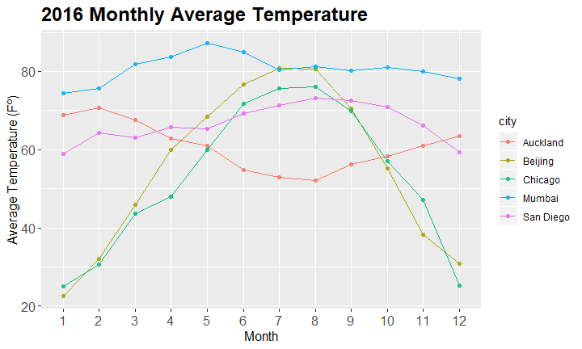

- To break things down further, here is a look at the average temperature for each city in 2016.
- It is evident that Auckland lies in the Southern Hemisphere while the other cities lie in the Northern Hemisphere.
- Auckland increases temperature while the other cities’ average temperatures decrease and vice versa.

## **Average Monthly Temperatures for All Cities for 2017**

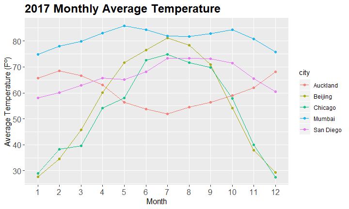

- Similar temperature patterns are shown in 2017 with slight fluctuations.
- We also notice that Mumbai has overall the highest temperature because it is closest to the equator.

## **Average Monthly Dewpoints for All Cities for 2016**

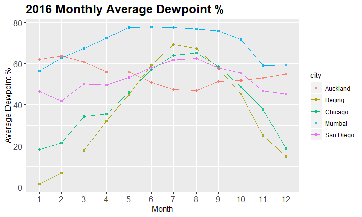

- Average dewpoint percentages show similar results to average temperatures as dewpoint is defined as the measure of how much moisture is in the air.

## **Average Monthly Dewpoints for All Cities for 2017**

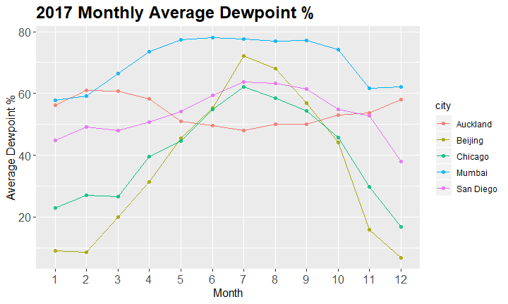

- Again here is the overall year of 2017 showing the dewpoint monthly average percentages for each of the 5 cities.

## **Average Monthly Humidity for All Cities for 2016**

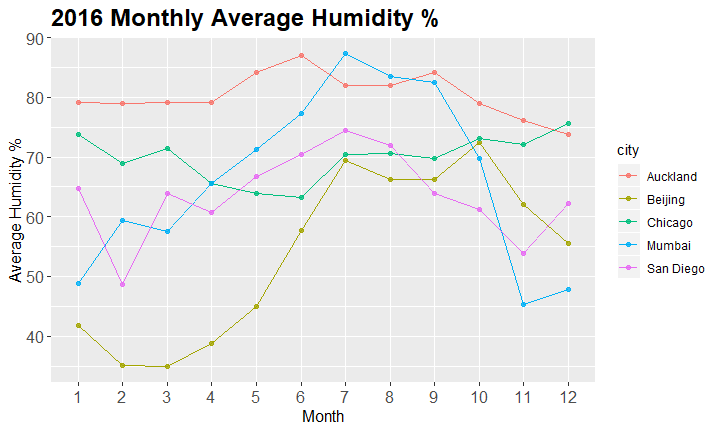

## **Average Monthly Humidity for All Cities for 2017**

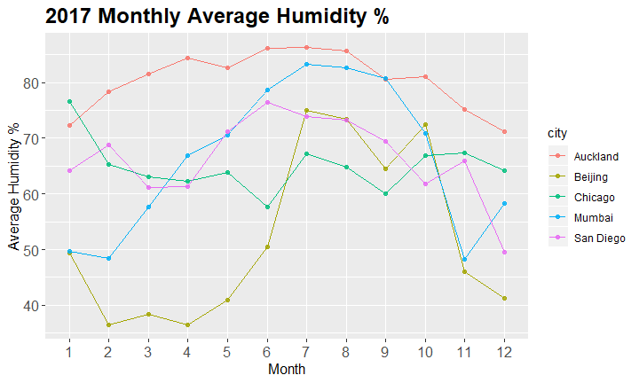

- In 2017, the overall humidity greatly resembles that of 2016 for these major cities.

## **Chaning NA’s for Events Column**

```r
weather$events<- as.character(weather$events)
weather$events[is.na(weather$events)] <- "Clear Skies"
skies <- weather %>%
  select(city, events)
```

- We had NA’s in the Weathering Events Column. But since we wanted to find out the types of weather events each city had, we changed the NA into “Clear Skies”.

## **Auckland Weather Events**

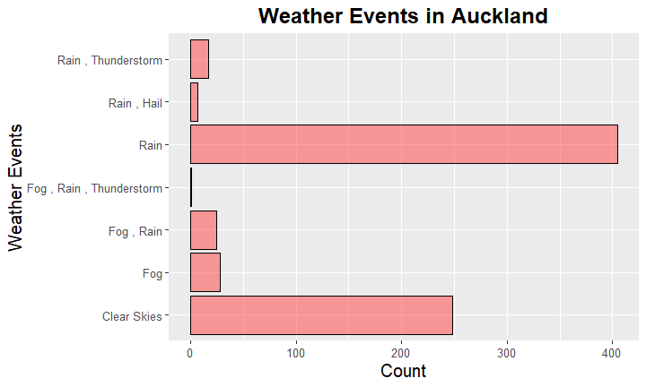

- Auckland’s weathering events are a bit of a surprise; rain takes precedence over clear skies.

## **Beijing Weather Events**

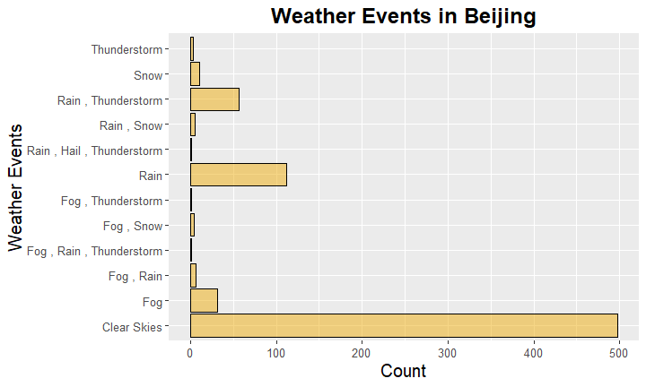

- Beijing’s full of days with clear skies within these two years. Rain trails along as the next common weathering event.

## **Chicago Weather Events**

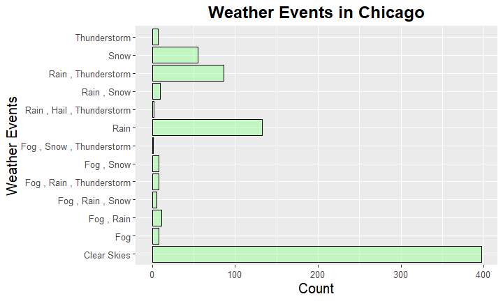

- As expected, Chicago shows variation throughout the two years with a variety of different patterns. However, Chicago still maintains its days with clear skies as higher than any other weathering event.

## **Mumbai Weather Events**

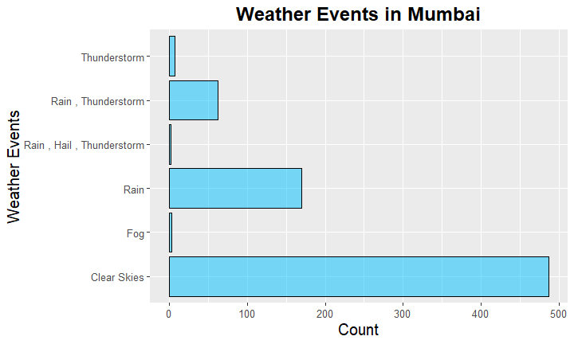

- For a majority of the year, Mumbai shows clear skies. Rainy days are not as common as clear skies but appear more frequently than any other weather event or combinations of events.

## **San Diego Weather Events**

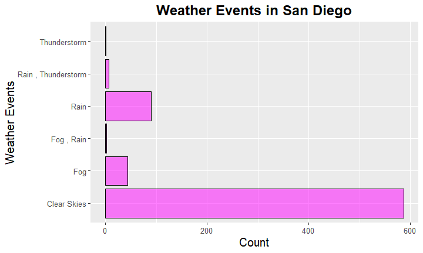

- San Diego as predicted has a majority of clear skies throughout the two years of data.
- They don’t call it “Sunny San Diego” for nothing!